# 线性代数：机器学习背后的优化原理

#### 1.1.2

**根据上面例题展示，绘制方程组，说明是否有解是否为唯一解，若有解需计算出方程组的解** $$ \begin{cases} y = 2x + 1\\\\ y = \frac{1}{10}x+6 \end{cases} $$

```
Matrix vw:
[[2.  1. ]
 [0.1 6. ]]

Vector t:
[1 1]

Vector is within span.
Scalars in s: [0.42016807 0.15966387]
```

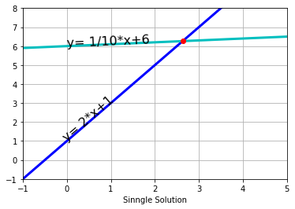

```python
# 1.1.2 TODO
import math

def check_vector_span(set_of_vectors, vector_to_check):
    # Creates an empty vector of correct size
    vector_of_scalars = np.asarray([None]*set_of_vectors.shape[0])

    # Solves for the scalars that make the equation true if vector is within the span
    try:
        # Use np.linalg.solve() function here to solve for vector_of_scalars
        vector_of_scalars = np.linalg.solve(set_of_vectors, vector_to_check)
        if not (vector_of_scalars is None):
            print("\nVector is within span.\nScalars in s:", vector_of_scalars)

    # Handles the cases when the vector is NOT within the span
    except Exception as exception_type:
        if str(exception_type) == "Singular matrix":
            print("\nNo single solution\nVector is NOT within span")
        else:
            print("\nUnexpected Exception Error:", exception_type)
    return vector_of_scalars


# Creates matrix t (right side of the augmented matrix).
t = np.array([1, 1])

# Creates matrix vw (left side of the augmented matrix).
vw = np.array([[2, 1], [1/10, 6]])

# Prints vw and t
print("\nMatrix vw:", vw, "\nVector t:", t, sep="\n")

s = check_vector_span(vw,t)

# x1 = (0-1) / 2
# y1 = 2*0 + 1
# x2 = (0-6) / (1/10)
# y2 = 1/10*0 + 6
# print((x1,y1))
# print((x2,y2))
# plt.plot([x1,0], [0,y1],'b',linewidth=3)
# plt.plot([x2,0], [0,y2],'c', linewidth=3)

x1a = -1
y1a = 2 * x1a + 1
x1b = 8
y1b = 2 * x1b + 1
# 把线拉长！！！
# print("lll",(x1a,y1a))
# print("222",(x1b,y1b))

x2a = -1
y2a = 1/10 * x2a + 6
x2b =8
y2b = 1/10 * x2b + 6

plt.plot([x1a,x1b], [y1a,y1b],'b',linewidth=3) #坐标的范围
plt.plot([x2a,x2b], [y2a,y2b],'c', linewidth=3)


plt.plot([50/19],[119/19],'ro',linewidth=3)

plt.xlim(-1,5)
major_xticks = np.arange(-1, 5)
ax.set_xticks(major_xticks)


plt.ylim(-1, 8)
major_xticks = np.arange(-1, 8)
ax.set_xticks(major_xticks)


# Locations to plot text
yl1 = 2 * 0 + 1
yl2 = 1/10 * 0 + 6
l1 = np.array((0, yl1))
l2 = np.array((0, yl2))

# Rotate angle
ag1 = math.degrees(math.atan(2))# 2.如果rotation = ag1 这个旋转角度很奇怪
ag2 = math.degrees(math.atan(1/10))

#3.修改：理解为 1要获得当前图形的座标轴.2使用的坐标系为数据坐标系(ax1.transData)可以通过绘出的坐标轴读出数据坐标的位置.
#3变换角 将直线对应斜率的角度对应上 文字坐标 （一直没搜到.transform_angles（）的用法）4将向量里的数取出来
angle1 = plt.gca().transData.transform_angles(np.array((ag1,)),
                                                   l1.reshape((1, 2)))[0]
angle2 = plt.gca().transData.transform_angles(np.array((ag2,)),
                                                   l2.reshape((1, 2)))[0]

# Plot text
th1 = plt.text(l1[0], l1[1], 'y= 2*x+1', fontsize=16,
               rotation= angle1, rotation_mode='anchor')
th2 = plt.text(l2[0], l2[1], 'y= 1/10*x+6', fontsize=16,
               rotation= angle2, rotation_mode='anchor')



plt.xlabel('Sinngle Solution')
plt.grid()
plt.show()
```

### 1.2、说明题

#### 1.2.1

**使用numpy（或自写算法）说明$(AB)^{\text{T}} = B^\text{T}A^\text{T}$**

**其中** $$ A=\begin{bmatrix} 21 & 7 \\\\ 15 & 42 \\\\ 9 & 6 \end{bmatrix}, B=\begin{bmatrix} 4 \\\\ 33 \end{bmatrix} $$

```python
# 1.2.1 TODO
A = np.array([[21,7],[15,42],[9,6]])
B = np.array([[4],[33]])
print('A=\n',A,'\n','B=\n',B)

AB = np.matmul(A ,B)
ABT = AB.T

BT = B.T
AT = A.T
BTAT = np.matmul(BT,AT)

print('AB=',AB)
print('ABT=',ABT)
print('BT=',BT)
print('AT=',AT)
print('BTAT=',BTAT)

print(ABT==BTAT)
```

```
A=
 [[21  7]
 [15 42]
 [ 9  6]]
 B=
 [[ 4]
 [33]]
AB= [[ 315]
 [1446]
 [ 234]]
ABT= [[ 315 1446  234]]
BT= [[ 4 33]]
AT= [[21 15  9]
 [ 7 42  6]]
BTAT= [[ 315 1446  234]]
[[ True  True  True]]
```

#### 1.2.2

**使用numpy（或自写算法）说明 $A ( B + C ) = AB + AC$**

**其中** $$ A=\begin{bmatrix} 9 & 3 \\\\ 8 & 4 \\\\ 7 & 6 \end{bmatrix}, B=\begin{bmatrix} 5 \\\\ 2 \end{bmatrix}, C=\begin{bmatrix} 5 \\\\ 7 \end{bmatrix} $$

```python
# 1.2.2 TODO
A = np.array([[9,3],[8,4],[7,6]])
B = np.array([[5],[2]])
C = np.array([[5],[7]])
ABC = np.matmul(A,B+C)
AB = np.matmul(A,B)
AC = np.matmul(A,C)
ABAC = AB+AC
print(ABC==ABAC)
```

```
[[ True]
 [ True]
 [ True]]
```

## 2、特殊矩阵

- 单位矩阵

如果选取任意一个向量和某矩阵相乘，该向量都不会改变，我们将这种保持n维向量不变的矩阵记为单位矩阵$I_n$

- 逆矩阵

如果存在一个矩阵，使$A^{-1} A = I_n$，那么$A^{-1}$就是A的逆矩阵。

- 对角矩阵

如果一个矩阵只有主对角线上还有非零元素，其他位置都是零，这个矩阵就是对角矩阵

- 对称矩阵

如果一个矩阵的转置是和它自己相等的矩阵，即$A=A^{T}$，那么这个矩阵就是对称矩阵

- 正交矩阵

行向量和列向量是分别标准正交(90度)的方阵，即$A^{T}A = AA^{T} = I_n$，又即$A^{-1} = A^{T}$，那么这种方阵就是正交矩阵

### 2.1、证明题

通过LaTeX公式，结合上面所述概念，假设$A^{-1}$存在的情况下，证明$Ax=b$的解$x={A}^{-1}{b}$

回答：

$A^{-1} A = I_n$

$A^{-1} = I_n / A$

$x = A^{-1}*b = I_n / A * b$

$A * x = A * (I_n / A * b) = A * I_n / A * b = I_n * b = b$

A的逆并非单位矩阵除以A来求得的哦 关于这道题的证明，因为我们的甲的逆存在，那么在左右两边同时乘以甲的逆，继续推导就可以得出证明结果，或者使用代入证明也可以

订正：

因为 $A^{-1}$ 存在，不为零， $A*x = b$ 等式两边同乘 $A^{-1}$ :

$\hspace{5cm}A^{-1}*A*x = A^{-1}*b $

因为 $A^{-1} * A = I_n$ ，所以：

$\hspace{5cm} I_n * x = A^{-1}*b $

因为乘以的是单位矩阵，所以 $ I_n * x = x $ ，所以：

$\hspace{5cm} x = A^{-1} * b $

### 2.2、 计算题

#### 2.2.1

通过numpy计算，再次验证2.1证明题 $$ \begin{cases} y = 2x + 1\\\\ y = \frac{1}{10}x+6 \end{cases} $$ 并用LaTeX公式写出$A^{-1}$是多少（小数分数皆可）